# Predicting individual medical costs billed by health insurance - using Linear Regression Model

We will build a Linear regression model for Medical cost dataset. The dataset consists of age, sex, BMI(body mass index), children, smoker and region feature, which are independent and charge as a dependent feature. We will predict individual medical costs billed by health insurance.

```python
#importing libraries
import numpy as np
import pandas as pd
import matplotlib.pyplot as plt
import seaborn as sns
from sklearn.model_selection import train_test_split
from sklearn.linear_model import LinearRegression
from sklearn import metrics
import warnings
warnings.filterwarnings('ignore')
```

```python
# loading the data from csv file to a Pandas DataFrame
insurance_dataset = pd.read_csv('insurance data.csv')
```

```python
# first 5 rows of the dataframe
insurance_dataset.head()
```

|  | age | sex | bmi | children | smoker | region | charges |
| --- | --- | --- | --- | --- | --- | --- | --- |
| 0 | 19 | female | 27.900 | 0 | yes | southwest | 16884.92400 |
| 1 | 18 | male | 33.770 | 1 | no | southeast | 1725.55230 |
| 2 | 28 | male | 33.000 | 3 | no | southeast | 4449.46200 |
| 3 | 33 | male | 22.705 | 0 | no | northwest | 21984.47061 |
| 4 | 32 | male | 28.880 | 0 | no | northwest | 3866.85520 |

```python
# last 5 rows of the dataframe
insurance_dataset.tail()
```

|  | age | sex | bmi | children | smoker | region | charges |
| --- | --- | --- | --- | --- | --- | --- | --- |
| 1333 | 50 | male | 30.97 | 3 | no | northwest | 10600.5483 |
| 1334 | 18 | female | 31.92 | 0 | no | northeast | 2205.9808 |
| 1335 | 18 | female | 36.85 | 0 | no | southeast | 1629.8335 |
| 1336 | 21 | female | 25.80 | 0 | no | southwest | 2007.9450 |
| 1337 | 61 | female | 29.07 | 0 | yes | northwest | 29141.3603 |

```python
# number of rows and columns
insurance_dataset.shape
```

```
(1338, 7)
```

```python
# getting some informations about the dataset
insurance_dataset.info()
```

```
<class 'pandas.core.frame.DataFrame'>
RangeIndex: 1338 entries, 0 to 1337
Data columns (total 7 columns):
 #   Column    Non-Null Count  Dtype
---  ------    --------------  -----
 0   age       1338 non-null   int64
 1   sex       1338 non-null   object
 2   bmi       1338 non-null   float64
 3   children  1338 non-null   int64
 4   smoker    1338 non-null   object
 5   region    1338 non-null   object
 6   charges   1338 non-null   float64
dtypes: float64(2), int64(2), object(3)
memory usage: 73.3+ KB
```

```python
# statistical Measures of the dataset
insurance_dataset.describe()
```

|  | age | bmi | children | charges |
| --- | --- | --- | --- | --- |
| count | 1338.000000 | 1338.000000 | 1338.000000 | 1338.000000 |
| mean | 39.207025 | 30.663397 | 1.094918 | 13270.422265 |
| std | 14.049960 | 6.098187 | 1.205493 | 12110.011237 |
| min | 18.000000 | 15.960000 | 0.000000 | 1121.873900 |
| 25% | 27.000000 | 26.296250 | 0.000000 | 4740.287150 |
| 50% | 39.000000 | 30.400000 | 1.000000 | 9382.033000 |
| 75% | 51.000000 | 34.693750 | 2.000000 | 16639.912515 |
| max | 64.000000 | 53.130000 | 5.000000 | 63770.428010 |

```python
# checking for missing values
insurance_dataset.isnull().sum()
```

```
age         0
sex         0
bmi         0
children    0
smoker      0
region      0
charges     0
dtype: int64
```

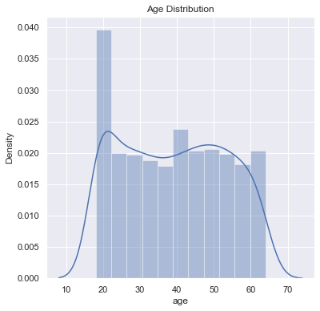

```python
# Distribution of age in the dataset
sns.set()
plt.figure(figsize=(6,6))
sns.distplot(insurance_dataset['age'])
plt.title('Age Distribution')
plt.show()
```

```python
insurance_dataset['sex'].value_counts()
```

```
male      676
female    662
Name: sex, dtype: int64
```

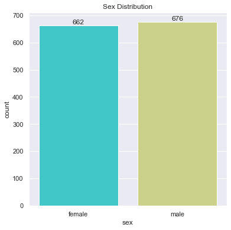

```python
# Finding gender distribution
plt.figure(figsize=(6,6))
ax=sns.countplot(x='sex', data=insurance_dataset,palette='rainbow')
for i in ax.containers:
    ax.bar_label(i,)
plt.title('Sex Distribution')
plt.show()
```

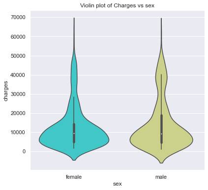

```python
f = plt.figure(figsize=(14,6))
ax = f.add_subplot(121)
sns.violinplot(x='sex', y='charges',data=insurance_dataset,palette='rainbow',ax=ax)
ax.set_title('Violin plot of Charges vs sex')
```

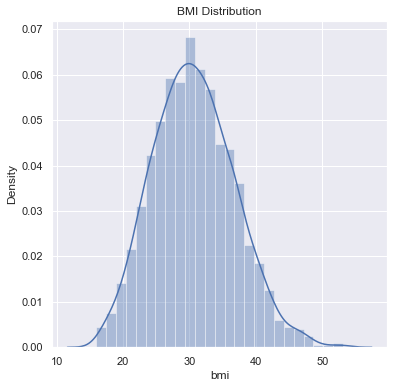

```python
# finding bmi distribution
sns.set()
plt.figure(figsize=(6,6))
sns.distplot(insurance_dataset['bmi'])
plt.title('BMI Distribution')
plt.show()
```

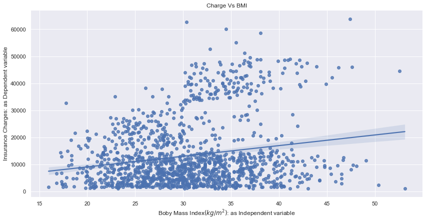

```python
sns.lmplot(x='bmi',y='charges',data=insurance_dataset,aspect=2,height=6)
plt.xlabel('Boby Mass Index$(kg/m^2)$: as Independent variable')
plt.ylabel('Insurance Charges: as Dependent variable')
plt.title('Charge Vs BMI');
```

In above plot we fit regression line into the variables.

```python
insurance_dataset['children'].value_counts()
```

```
0    574
1    324
2    240
3    157
4     25
5     18
Name: children, dtype: int64
```

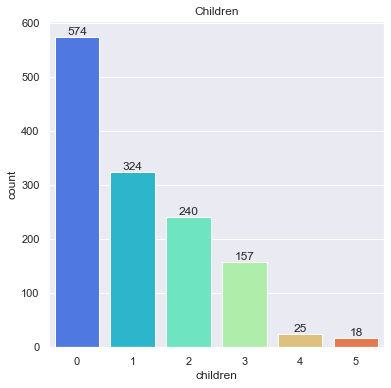

```python
# children column
plt.figure(figsize=(6,6))
ax=sns.countplot(x='children', data=insurance_dataset,palette='rainbow')
for i in ax.containers:
    ax.bar_label(i,)
plt.title('Children')
plt.show()
```

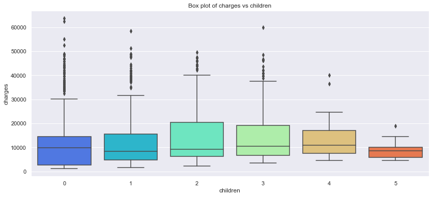

```python
plt.figure(figsize=(14,6))
sns.boxplot(x='children', y='charges',data=insurance_dataset,palette='rainbow')
plt.title('Box plot of charges vs children');
```

In the Above graph we have used Box plot to show outliers in the count of children.

```python
insurance_dataset['smoker'].value_counts()
```

```
no     1064
yes     274
Name: smoker, dtype: int64
```

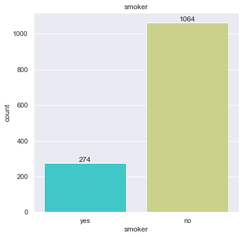

```python
# finding smokers count
plt.figure(figsize=(6,6))
ax=sns.countplot(x='smoker', data=insurance_dataset,palette='rainbow')
for i in ax.containers:
    ax.bar_label(i,)
plt.title('smoker')
plt.show()
```

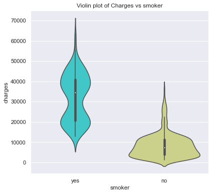

```python
f = plt.figure(figsize=(14,6))
ax = f.add_subplot(121)
sns.violinplot(x='smoker', y='charges',data=insurance_dataset,palette='rainbow',ax=ax)
ax.set_title('Violin plot of Charges vs smoker')
```

```python
insurance_dataset['region'].value_counts()
```

```
southeast    364
southwest    325
northwest    325
northeast    324
Name: region, dtype: int64
```

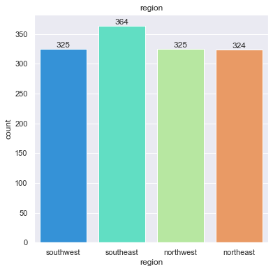

```python
# region column
plt.figure(figsize=(6,6))
ax=sns.countplot(x='region', data=insurance_dataset,palette='rainbow')
for i in ax.containers:
    ax.bar_label(i,)
plt.title('region')
plt.show()
```

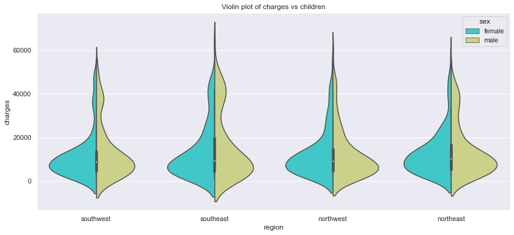

```python
plt.figure(figsize=(14,6))
sns.violinplot(x='region', y='charges',hue='sex',data=insurance_dataset,palette='rainbow',split=True)
plt.title('Violin plot of charges vs children');
```

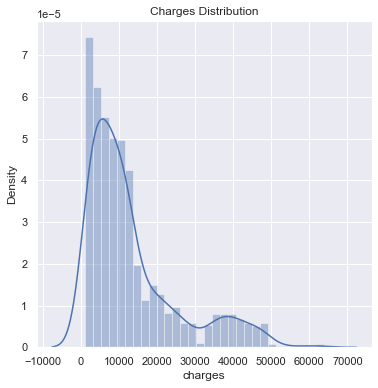

```python
# distribution of charges value
plt.figure(figsize=(6,6))
sns.distplot(insurance_dataset['charges'])
plt.title('Charges Distribution')
plt.show()
```

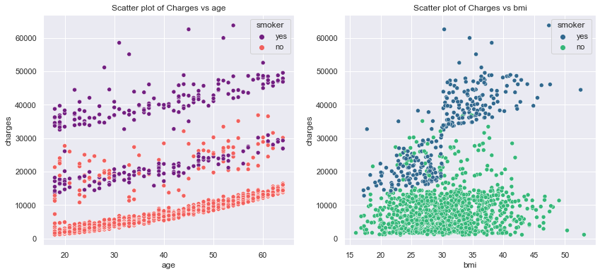

```python
f = plt.figure(figsize=(14,6))
ax = f.add_subplot(121)
sns.scatterplot(x='age',y='charges',data=insurance_dataset,palette='magma',hue='smoker',ax=ax)
ax.set_title('Scatter plot of Charges vs age')

ax = f.add_subplot(122)
sns.scatterplot(x='bmi',y='charges',data=insurance_dataset,palette='viridis',hue='smoker')
ax.set_title('Scatter plot of Charges vs bmi')
plt.savefig('sc.png');
```

From left plot the minimum age person is insured is 18 year. There is slabs in policy most of non smoker take 1st and 2nd slab, for smoker policy start at 2nd and 3rd slab.

Body mass index (BMI) is a measure of body fat based on height and weight that applies to adult men and women. The minimum bmi is 16 kg/m2 and maximum upto 54 kg/m2

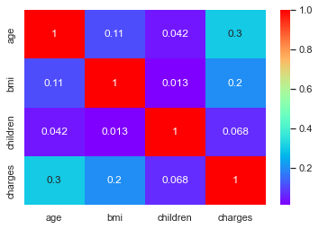

```python
# Building correlation matrix
corr =insurance_dataset .corr()
sns.heatmap(corr, cmap = 'rainbow', annot= True)
```

Data Pre-Processing

Encoding the categorical features

categorical features

1)sex

2)smoker

3)region

```python
# encoding sex column
insurance_dataset.replace({'sex':{'male':0,'female':1}}, inplace=True)

3 # encoding 'smoker' column
insurance_dataset.replace({'smoker':{'yes':0,'no':1}}, inplace=True)

# encoding 'region' column
insurance_dataset.replace({'region':{'southeast':0,'southwest':1,'northeast':2,'northwest':3}}, inplace=True)
```

Splitting the Features and Target

```python
X = insurance_dataset.drop(columns='charges', axis=1)
Y = insurance_dataset['charges']
```

Splitting the data into Training data & Testing Data

```python
X_train, X_test, Y_train, Y_test = train_test_split(X, Y, test_size=0.3, random_state=2)
```

```python
print(X.shape, X_train.shape, X_test.shape)
```

```
(1338, 6) (936, 6) (402, 6)
```

```python
print(Y.shape, Y_train.shape, Y_test.shape)
```

```
(1338,) (936,) (402,)
```

Model Training

Linear Regression

```python
# loading the Linear Regression model
regressor = LinearRegression()
regressor.fit(X_train, Y_train)
```

```
LinearRegression()
```

Model Evaluation

```python
# prediction on training data
Y_prediction =regressor.predict(X_test)
```

```python
Y_test
```

```
17       2395.17155
1091    11286.53870
273      9617.66245
270      1719.43630
874      8891.13950
           ...
468     23288.92840
1232    12479.70895
682     40103.89000
86      43578.93940
164      5028.14660
Name: charges, Length: 402, dtype: float64
```

```python
#calculating the coeffiecients
print(regressor.coef_)
```

```
[   244.92327173    113.95426496    340.08819797    611.17594904
 -23389.2680485     180.61422029]
```

```python
#calculating the Intercept
print(regressor.intercept_)
```

```
10814.460500490752
```

```python
# prediction on test data
Y_prediction =regressor.predict(X_test)
```

```python
# R squared value
r2_test = metrics.r2_score(Y_test, Y_prediction)
print('R squared vale : ', r2_test)
```

```
R squared vale :  0.766118606810119
```

```python
from sklearn import metrics
meanAbErr = metrics.mean_absolute_error(Y_test, Y_prediction)
meanSqErr = metrics.mean_squared_error(Y_test, Y_prediction)
rootMeanSqErr = np.sqrt(metrics.mean_squared_error(Y_test, Y_prediction))
r2_test = metrics.r2_score(Y_test, Y_prediction)
print('Mean Absolute Error:', meanAbErr)
print('Mean Square Error:', meanSqErr)
print('Root Mean Square Error:', rootMeanSqErr)
print('R squared vale : ', r2_test)
```

```
Mean Absolute Error: 4251.180538000687
Mean Square Error: 37804245.53227782
Root Mean Square Error: 6148.515717819856
R squared vale :  0.766118606810119
```

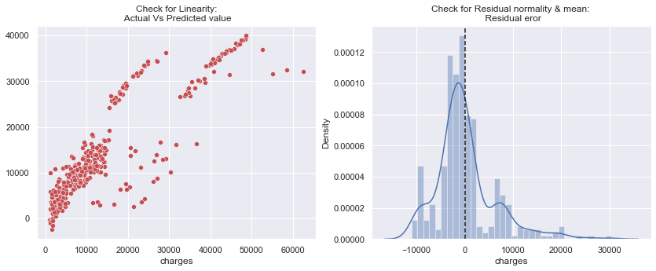

```python
# Check for Linearity
f = plt.figure(figsize=(14,5))
ax = f.add_subplot(121)
sns.scatterplot(Y_test,Y_prediction,ax=ax,color='r')
ax.set_title('Check for Linearity:\n Actual Vs Predicted value')

# Check for Residual normality & mean
ax = f.add_subplot(122)
sns.distplot((Y_test - Y_prediction),ax=ax,color='b')
ax.axvline((Y_test - Y_prediction).mean(),color='k',linestyle='--')
ax.set_title('Check for Residual normality & mean: \n Residual eror');
```

In our model the actual vs predicted plot is curve so linear assumption fails The residual mean is zero and residual error plot right skewed

```python
# Check for Multicollinearity
#Variance Inflation Factor
VIF = 1/(1- r2_test)
VIF
```

```
4.275671469034441
```

Variance inflation factor value is less than 5, so no multicollearity.

Building a Predictive System

```python
input_data = (31,1,25.74,0,1,0)
```

```python
# changing input_data to a numpy array
input_data_as_numpy_array = np.asarray(input_data)
```

```python
# reshape the array
input_data_reshaped = input_data_as_numpy_array.reshape(1,-1)
```

```python
prediction = regressor.predict(input_data_reshaped)
print(prediction)
```

```
[3885.63835645]
```

The insurance cost is USD 3885.63835645